# Predicting Pregnancy Outcome in Rural Areas Using Machine Learning Methods

### This analysis is performed using Data published by Natioanal Health Mission - Annual Health Survey

"Health is not everything but everything else is nothing without health". Heath infrastructure that has been setup in urban India is far ahead than the lean healthcare facilities available in Rural areas. We have more than 70% of population in rural areas with very basic primary medical facilities and hence they have to travel to cities to avail better medical facilities from private setups which goes heavy on their pockets.

While watching a news report on Social, Economic and Medical challenges faced by HIV patient in rural areas, I picked up this topic to understand :

1. Pregnancy outcomes in rural India and how it gets impacted from several factors like - ANC and other medical checkups, financial assistance, education of parents etc.
2. Later I tried to Predict the outcome of pregnancy using same data which can be easily collected at Primary Health care centers

This is a very limited/simple study which gives us confidence that we can build more comprehensive models which can predict the pregnancy outcome in these financially challenged area based on some manual collected stats, medical records, scan reports etc. These models might help in augmenting the tools/capabilities of medical professionals at rural healthcare centers and help them in taking necessary steps in identifying and dealing with high risk cases.

I am using the NRHM - AHS Survey results for "Bihar" published at https://nrhm-mis.nic.in/hmisreports/AHSReports.aspx

```python
import matplotlib.pyplot as plt
%matplotlib inline
import numpy as np
from pandas import DataFrame, Series
import pandas as pd
from sklearn.model_selection import train_test_split
from sklearn import neighbors, svm, tree
from sklearn.utils import shuffle
from sklearn.feature_selection import SelectKBest,chi2
```

**This is the DataSet we are going to work upon.**

```python
data = pd.read_csv('AHS_Results.csv',delimiter='|',low_memory=False)
data.sample(2)
```

|  | twps_id | client_twps_id | w_id | serial_no | house_no | house_hold_no | state | district | rural | stratum_code | ... | as_binned | respondentname | rtelephoneno | isnewrecord | recordupdatedcount | recordstatus | schedule_id | year | id | v358 |
| --- | --- | --- | --- | --- | --- | --- | --- | --- | --- | --- | --- | --- | --- | --- | --- | --- | --- | --- | --- | --- | --- |
| 198434 | 2982.0 | 39494.0 | 7888.0 | 2 | 374 | 1 | 10 | 6 | 1 | 1 | ... | 3.0 | NaN | NaN | NaN | NaN | NaN | 3.0 | 3.0 | 1352691.0 | NaN |
| 331257 | 2870.0 | 58.0 | 9464.0 | 3 | 156 | 1 | 10 | 28 | 2 | 0 | ... | 5.0 | NaN | NaN | NaN | 1.0 | 2.0 | 3.0 | 3.0 | 1591260.0 | NaN |

2 rows × 355 columns

```python
data.shape
```

```
(360133, 355)
```

So we have got 300k+ data samples available. Lets see sample of the columns/features available. I am not listing all the columns here as it would make this page very big. Around 350 features are available.

```python
#Some random Columns
data.columns.values[10:25]
```

```
array(['psu_id', 'identifcation_code', 'age', 'marital_status',
       'w_preg_no', 'preg_flag', 'out_come_of_preg', 'year_of_abortion',
       'month_of_abortion', 'abortion_month', 'anc_status',
       'ultrsound_status', 'abortion_performed', 'abortion_performed_by',
       'reason_for_abortion'], dtype=object)
```

## 1. Data Analysis

### 1.1. Analyze pregnancy outcomes based on Age groups, which might be a major factor influencing the pregnancy results. See results per thousand

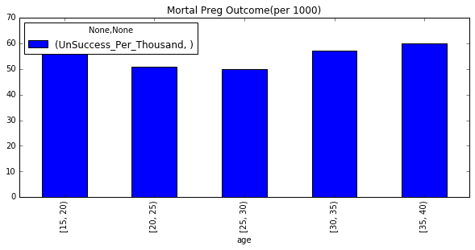

```python
age_bins = [15,20,25,30,35,40]
cats = pd.cut(data.age,age_bins,right=False)

dx = data.groupby([cats,['Success' if x == 1 else 'UnSuccess' for x in data.out_come_of_preg]])\
[['out_come_of_preg']].count().unstack(1)

#Calculate per Thousand Values

dx['Success_Per_Thousand'],dx['UnSuccess_Per_Thousand'] = \
    ((dx['out_come_of_preg']['Success'])/dx.sum(1)*1000).astype(int),\
    ((dx['out_come_of_preg']['UnSuccess'])/dx.sum(1)*1000).astype(int)

dx[['UnSuccess_Per_Thousand']].plot(kind='bar',title='Mortal Preg Outcome(per 1000)',figsize=(10,4))
```

AHS also published metadata at the same website which I will be using to understand the data availale

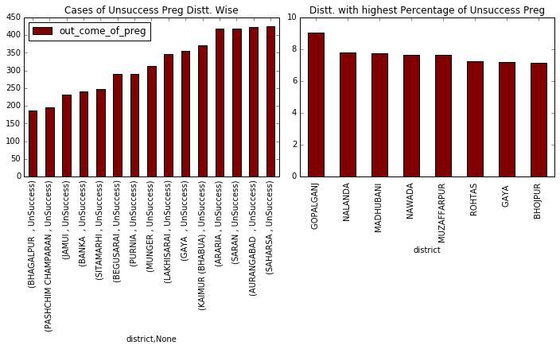

```python
xls_file = pd.ExcelFile('Data_structure_AHS.xlsx')
table = xls_file.parse('State District Codes',header=1,index_col=1)
table2 = table[table["State Code"] == 10]
table3 = table2[table2.index.to_series().notnull()].ix[:,[1]]

#Covert this to a dict which I can use for easy lookups
zz = table3.to_dict('dict')[u'District Name']

# Use the dict with District Information to get district level stats
dist_grp = data.groupby([data.district.map(zz),['Success' if x == 1 else 'UnSuccess' for  x in data.out_come_of_preg]])\
                [['out_come_of_preg']].count()


# plot the data
fig = plt.figure()

ax = fig.add_subplot(1,2,1)
dist_grp[dist_grp.index.get_level_values(1).isin(['UnSuccess'])]\
                    .sort_values(by='out_come_of_preg')[:15].\
                        plot(kind='bar',figsize=(10,6),color='maroon',title='Cases of Unsuccess Preg Distt. Wise',ax=ax)


ax1 = fig.add_subplot(1,2,2)

(dist_grp.unstack(1)['out_come_of_preg','UnSuccess']/dist_grp.unstack(1).sum(1)*100)\
            .sort_values(ascending=False).head(8)\
            .plot(kind='bar',figsize=(10,6),color='maroon',title='Distt. with highest Percentage of Unsuccess Preg',ax=ax1)
fig.tight_layout(pad=0.4, w_pad=0.5, h_pad=1.0)
```

### 1.3. % Coparision of ANC Performed

```
(-1.0450780928705803, 1.0, -1.0184938909107037, 1.1067944879532035)
```

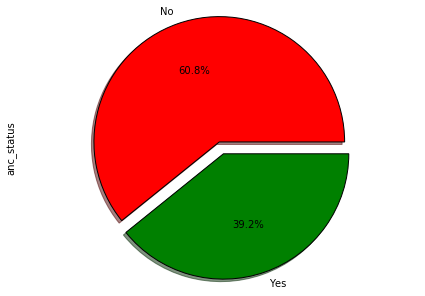

```python
data.anc_status.map(dict([[int(x.split('-')[1]),x.split('-')[0]] for x in \
              data_dict[data_dict['Field Name'] == 'anc_status']['Codes Used'].values[0].split(',')])).value_counts()\
            .plot(kind='pie',explode = (0.1, 0),autopct='%1.1f%%',colors='rg',shadow=True)

plt.tight_layout()
plt.axis('equal')
```

### Inference

> > - 60% of cases are still with No ANC done. (ANC is Antenatal care that women receive from healthcare professionals)

### 1.4. Major Reasons for Abortions

```python
data['reason_for_abortion'].map(dict([[int(x.split('-')[1]),x.split('-')[0]] for x in \
              data_dict[data_dict['Field Name'] == 'reason_for_abortion']['Codes Used'].values[0].split(',')])).value_counts()
```

```
Unplanned pregnancy                  637
Last child too young                 600
Health did not permit                456
Others                               395
Economic reason(s)                   332
Due to contraceptive failure         271
Female foetus                        221
Complication(s) in pregnancy         158
Foetus had congenital abnormality     57
Name: reason_for_abortion, dtype: int64
```

### 1.5. % Coparision of Gender of Newborns

```
(-1.0178114396977822, 1.0, -1.0197482013228898, 1.1084548323785737)
```

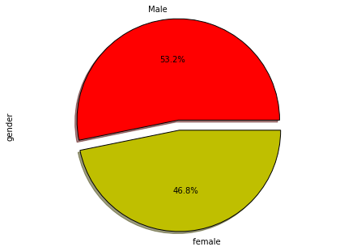

```python
# Load the Data Descriptions.

table2 = xls_file.parse('WPS',header=1,index_col=0)
data_dict = table2.ix[:,[0,1,2]]

data.gender.map(dict([[int(x.split('-')[1]),x.split('-')[0]] for x in \
              data_dict[data_dict['Field Name'] == 'gender']['Codes Used'].values[0].split(',')])).value_counts()\
            .plot(kind='pie',explode = (0.1, 0),autopct='%1.1f%%',colors='ry',shadow=True)

plt.tight_layout()
plt.axis('equal')
```

## 2. Build a Predictive Model for Pregnancy Outcome on the easily available Features

### Manual Features Selection

```python
# Master Features List which I think will be critical and will be easlity available at PHCs
features = ('''age
rural
preg_flag
anc_status
ultrsound_status
consumption_of_ifa
maternity_financial_asistance
consumption_of_ifax
consumption_of_ifa_syrup
swelling_of_hand_feet_face
paleness_giddiness_weakness
visual_disturbance
excessive_fatigue
convulsion_not_from_fever
weak_or_no_movement_foetus
abnormal_position_foetus
excessive_vomiting
hypertension_high_bp
jaundice
excessive_bleeding
other_preg_problems
treatment_for_preg_prob
pregnancy_number_q91
house_structure
chew
smoke
alcohol
highest_qualification
previous_current_diff
out_come_of_preg''').split('\n')
```

#### These fields seem to have lot of NULL values but they could be important factors effecting the outcome, lets get the default values filled for NULLs

Replace the missing values based on the Data Descriptions from data_dict

```python
filler = {'anc_status':2,'ultrsound_status':2,'consumption_of_ifa':3,'where_del_took_place':99,
'maternity_financial_asistance':4,'consumption_of_ifax':0,'consumption_of_ifa_syrup':0,'consumption_of_ifa_syrup':2,
 'swelling_of_hand_feet_face':2, 'paleness_giddiness_weakness':2, 'visual_disturbance':2, 'excessive_fatigue':2,
 'convulsion_not_from_fever':2, 'weak_or_no_movement_foetus':2, 'abnormal_position_foetus':2, 'excessive_vomiting':2,
 'hypertension_high_bp':2, 'jaundice':2, 'excessive_bleeding':2, 'other_preg_problems':2, 'treatment_for_preg_prob':2,
 'treatment_from_for_preg_prob':99, 'pregnancy_number_q91':1, 'house_structure':4, 'chew':0, 'smoke':0, 'alcohol':0,
 'highest_qualification':0, 'previous_current_diff':99, 'out_come_of_preg':1.}

health_data = health_data1.fillna(filler)
```

```python
#Drop the samples which have most of fields as blank
health_data1 = shuffle(data[features].dropna(thresh=25)).copy()

# Convert the filed preg_flag to numerical labels
health_data1['preg_flag_2'] = health_data1.preg_flag.factorize()[0]
health_data1 = health_data1.drop('preg_flag',axis=1)
```

### Dimensionality Reduction - Filtering out 15 best features

```python
X = health_data.ix[:,range(0,28)+[29]].values
```

```python
Y = health_data.out_come_of_preg.values
```

We will use Chi Square method to identify features which are impacting the pregnancy outcome most. We will use SelectkBest which removes all but the k highest scoring features (sklearn documentation)

```python
model_best = SelectKBest(chi2,k=15).fit(X,Y)
model_best.get_support()
```

```
array([ True, False,  True,  True, False,  True,  True,  True,  True,
        True, False,  True, False, False, False, False, False, False,
       False, False,  True,  True,  True, False, False, False,  True,
        True,  True], dtype=bool)
```

```python
X_new = model_best.transform(X)
```

# Build Models - Support Vector Classifier, KNN and Decision Tree

```python
x_train,x_test,y_train,y_test =  train_test_split(X_new,Y,test_size=.2)
```

### 1. Support Vector Classifier

```python
model_svm = svm.SVC(kernel='linear')
```

```python
model_svm.fit(x_train,y_train)
```

```
SVC(C=1.0, cache_size=200, class_weight=None, coef0=0.0,
  decision_function_shape=None, degree=3, gamma='auto', kernel='linear',
  max_iter=-1, probability=False, random_state=None, shrinking=True,
  tol=0.001, verbose=False)
```

```python
model_svm.score(x_test,y_test)
```

```
0.98831565701959379
```

```python
predicted = model_svm.predict(x_test)
confusion = pd.DataFrame({'Actual':y_test,'Predicted':predicted})
results_svc = confusion.groupby(['Actual'])[['Actual']].count().join(confusion.groupby(['Predicted'])[['Predicted']].count())


results_svc
```

| Actual | Actual | Predicted |
| --- | --- | --- |
| 1.0 | 21986 | 22244.0 |
| 2.0 | 253 | NaN |
| 3.0 | 3 | 2.0 |
| 4.0 | 10 | 6.0 |

> > Doesn't seem to be predicting 2/3/4 class labels correctly

### 2. K- Nearest Neighbours

```python
model_knn = neighbors.KNeighborsClassifier(n_neighbors=10)
```

```python
model_knn.fit(x_train,y_train)
model_knn.score(x_test,y_test)
```

```
0.98804601833543049
```

```python
predicted = model_knn.predict(x_test)
confusion = pd.DataFrame({'Actual':y_test,'Predicted':predicted})
results_knn = confusion.groupby(['Actual'])[['Actual']].count().join(confusion.groupby(['Predicted'])[['Predicted']].count())

results_knn
```

| Actual | Actual | Predicted |
| --- | --- | --- |
| 1.0 | 21986 | 22252.0 |
| 2.0 | 253 | NaN |
| 3.0 | 3 | NaN |
| 4.0 | 10 | NaN |

> > This as well doesn't seem to be predicting 2/3/4 class labels correctly

### 3. Build Decision Tree

```python
model_tree = tree.DecisionTreeClassifier()
model_tree.fit(x_train,y_train)
```

```
DecisionTreeClassifier(class_weight=None, criterion='gini', max_depth=None,
            max_features=None, max_leaf_nodes=None,
            min_impurity_split=1e-07, min_samples_leaf=1,
            min_samples_split=2, min_weight_fraction_leaf=0.0,
            presort=False, random_state=None, splitter='best')
```

```python
model_tree.score(x_test,y_test)
```

```
0.98063095452094196
```

```python
predicted = model_tree.predict(x_test)
confusion = pd.DataFrame({'Actual':y_test,'Predicted':predicted})
results_tree = confusion.groupby(['Actual'])[['Actual']].count().join(confusion.groupby(['Predicted'])[['Predicted']].count())

results_tree
```

| Actual | Actual | Predicted |
| --- | --- | --- |
| 1.0 | 21986 | 22050 |
| 2.0 | 253 | 190 |
| 3.0 | 3 | 1 |
| 4.0 | 10 | 11 |

> > Decision Tree is giving the closest predictions

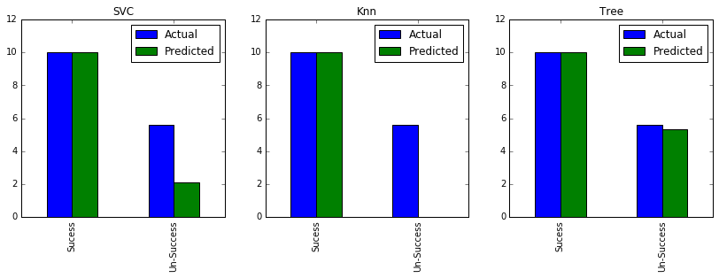

```python
fig = plt.figure()
ax = fig.add_subplot(1,3,1)
ax1 = fig.add_subplot(1,3,2)
ax2 = fig.add_subplot(1,3,3)

for results,axis,algo in zip([results_svc,results_knn,results_tree],[ax,ax1,ax2],['SVC','Knn','Tree']):
    np.log(results.groupby(['Sucess' if x==1 else 'Un-Success' for x in results.index])[['Actual','Predicted']]\
           .sum()).plot(kind='bar',ax=axis,figsize=(14,4),title=algo)
```

## Inference

> > We observe much better results by using Decision Tree Algorithm There is scope of further analysising this by using ensemble methods like Randon-Forests to further enhance the predectibity

### *Conclusion*

As we have observed in the data analysis that there are more than 60% pregnancies with even ANC not being done in rural India, this shows the scarcity of medical facilities. A recent survey by medical council of India shows for every 1681 citizens in India, there is only one doctor available.

This study also substantiates the fact that AI based systems can improve diagnosis for many medical conditions by studying past patient data and medical records. These AI systems can help collate the test reports of patients, aid diagnosis by deriving results from the patient’s data and medical records of similar symptoms and suggest diagnosis and treatment. This will help in improving efficiency of doctors, reduce errors and provide a more comprehensive care to patients in even isolated places.